# Covid Data Analysis

2023-07-19

## Covid Data Analysis

This report will analyze data about cases and deaths of the Covid 19 virus, reported both in the US and globaly. The data set used was provided by Johns Hopkins and is available on github. First we need to read in the four data sets.

## Cleaning Data

```r
library(tidyverse)
library(lubridate)
library(ggstatsplot)
```

```r
cov19_confirmed_us <- read_csv("https://raw.githubusercontent.com/CSSEGISandData/COVID-19/master/csse_covid_19_data/csse_covid_19_time_series/time_series_covid19_confirmed_US.csv")
head(cov19_confirmed_us)
```

```
## # A tibble: 6 × 1,154
##        UID iso2  iso3  code3  FIPS Admin2  Province_State Country_Region   Lat
##      <dbl> <chr> <chr> <dbl> <dbl> <chr>   <chr>          <chr>          <dbl>
## 1 84001001 US    USA     840  1001 Autauga Alabama        US              32.5
## 2 84001003 US    USA     840  1003 Baldwin Alabama        US              30.7
## 3 84001005 US    USA     840  1005 Barbour Alabama        US              31.9
## 4 84001007 US    USA     840  1007 Bibb    Alabama        US              33.0
## 5 84001009 US    USA     840  1009 Blount  Alabama        US              34.0
## 6 84001011 US    USA     840  1011 Bullock Alabama        US              32.1
## # ℹ 1,145 more variables: Long_ <dbl>, Combined_Key <chr>, `1/22/20` <dbl>,
## #   `1/23/20` <dbl>, `1/24/20` <dbl>, `1/25/20` <dbl>, `1/26/20` <dbl>,
## #   `1/27/20` <dbl>, `1/28/20` <dbl>, `1/29/20` <dbl>, `1/30/20` <dbl>,
## #   `1/31/20` <dbl>, `2/1/20` <dbl>, `2/2/20` <dbl>, `2/3/20` <dbl>,
## #   `2/4/20` <dbl>, `2/5/20` <dbl>, `2/6/20` <dbl>, `2/7/20` <dbl>,
## #   `2/8/20` <dbl>, `2/9/20` <dbl>, `2/10/20` <dbl>, `2/11/20` <dbl>,
## #   `2/12/20` <dbl>, `2/13/20` <dbl>, `2/14/20` <dbl>, `2/15/20` <dbl>, …
```

```r
cov19_deaths_us <- read_csv("https://raw.githubusercontent.com/CSSEGISandData/COVID-19/master/csse_covid_19_data/csse_covid_19_time_series/time_series_covid19_deaths_US.csv")
head(cov19_deaths_us)
```

```
## # A tibble: 6 × 1,155
##        UID iso2  iso3  code3  FIPS Admin2  Province_State Country_Region   Lat
##      <dbl> <chr> <chr> <dbl> <dbl> <chr>   <chr>          <chr>          <dbl>
## 1 84001001 US    USA     840  1001 Autauga Alabama        US              32.5
## 2 84001003 US    USA     840  1003 Baldwin Alabama        US              30.7
## 3 84001005 US    USA     840  1005 Barbour Alabama        US              31.9
## 4 84001007 US    USA     840  1007 Bibb    Alabama        US              33.0
## 5 84001009 US    USA     840  1009 Blount  Alabama        US              34.0
## 6 84001011 US    USA     840  1011 Bullock Alabama        US              32.1
## # ℹ 1,146 more variables: Long_ <dbl>, Combined_Key <chr>, Population <dbl>,
## #   `1/22/20` <dbl>, `1/23/20` <dbl>, `1/24/20` <dbl>, `1/25/20` <dbl>,
## #   `1/26/20` <dbl>, `1/27/20` <dbl>, `1/28/20` <dbl>, `1/29/20` <dbl>,
## #   `1/30/20` <dbl>, `1/31/20` <dbl>, `2/1/20` <dbl>, `2/2/20` <dbl>,
## #   `2/3/20` <dbl>, `2/4/20` <dbl>, `2/5/20` <dbl>, `2/6/20` <dbl>,
## #   `2/7/20` <dbl>, `2/8/20` <dbl>, `2/9/20` <dbl>, `2/10/20` <dbl>,
## #   `2/11/20` <dbl>, `2/12/20` <dbl>, `2/13/20` <dbl>, `2/14/20` <dbl>, …
```

```r
cov19_confirmed_global <- read_csv("https://raw.githubusercontent.com/CSSEGISandData/COVID-19/master/csse_covid_19_data/csse_covid_19_time_series/time_series_covid19_confirmed_global.csv")
head(cov19_confirmed_global)
```

```
## # A tibble: 6 × 1,147
##   `Province/State` `Country/Region`   Lat  Long `1/22/20` `1/23/20` `1/24/20`
##   <chr>            <chr>            <dbl> <dbl>     <dbl>     <dbl>     <dbl>
## 1 <NA>             Afghanistan       33.9 67.7          0         0         0
## 2 <NA>             Albania           41.2 20.2          0         0         0
## 3 <NA>             Algeria           28.0  1.66         0         0         0
## 4 <NA>             Andorra           42.5  1.52         0         0         0
## 5 <NA>             Angola           -11.2 17.9          0         0         0
## 6 <NA>             Antarctica       -71.9 23.3          0         0         0
## # ℹ 1,140 more variables: `1/25/20` <dbl>, `1/26/20` <dbl>, `1/27/20` <dbl>,
## #   `1/28/20` <dbl>, `1/29/20` <dbl>, `1/30/20` <dbl>, `1/31/20` <dbl>,
## #   `2/1/20` <dbl>, `2/2/20` <dbl>, `2/3/20` <dbl>, `2/4/20` <dbl>,
## #   `2/5/20` <dbl>, `2/6/20` <dbl>, `2/7/20` <dbl>, `2/8/20` <dbl>,
## #   `2/9/20` <dbl>, `2/10/20` <dbl>, `2/11/20` <dbl>, `2/12/20` <dbl>,
## #   `2/13/20` <dbl>, `2/14/20` <dbl>, `2/15/20` <dbl>, `2/16/20` <dbl>,
## #   `2/17/20` <dbl>, `2/18/20` <dbl>, `2/19/20` <dbl>, `2/20/20` <dbl>, …
```

```r
cov19_deaths_global <- read_csv("https://raw.githubusercontent.com/CSSEGISandData/COVID-19/master/csse_covid_19_data/csse_covid_19_time_series/time_series_covid19_deaths_global.csv")
head(cov19_deaths_global)
```

```
## # A tibble: 6 × 1,147
##   `Province/State` `Country/Region`   Lat  Long `1/22/20` `1/23/20` `1/24/20`
##   <chr>            <chr>            <dbl> <dbl>     <dbl>     <dbl>     <dbl>
## 1 <NA>             Afghanistan       33.9 67.7          0         0         0
## 2 <NA>             Albania           41.2 20.2          0         0         0
## 3 <NA>             Algeria           28.0  1.66         0         0         0
## 4 <NA>             Andorra           42.5  1.52         0         0         0
## 5 <NA>             Angola           -11.2 17.9          0         0         0
## 6 <NA>             Antarctica       -71.9 23.3          0         0         0
## # ℹ 1,140 more variables: `1/25/20` <dbl>, `1/26/20` <dbl>, `1/27/20` <dbl>,
## #   `1/28/20` <dbl>, `1/29/20` <dbl>, `1/30/20` <dbl>, `1/31/20` <dbl>,
## #   `2/1/20` <dbl>, `2/2/20` <dbl>, `2/3/20` <dbl>, `2/4/20` <dbl>,
## #   `2/5/20` <dbl>, `2/6/20` <dbl>, `2/7/20` <dbl>, `2/8/20` <dbl>,
## #   `2/9/20` <dbl>, `2/10/20` <dbl>, `2/11/20` <dbl>, `2/12/20` <dbl>,
## #   `2/13/20` <dbl>, `2/14/20` <dbl>, `2/15/20` <dbl>, `2/16/20` <dbl>,
## #   `2/17/20` <dbl>, `2/18/20` <dbl>, `2/19/20` <dbl>, `2/20/20` <dbl>, …
```

We now need to do some cleaning of the data. We will start by doing some minor reformatting and dropping the Lat and Long columns that won’t be used.

```r
cov19_confirmed_global <- cov19_confirmed_global %>%
  pivot_longer(cols = -c('Province/State', 'Country/Region', Lat, Long), names_to = 'date', values_to = 'cases') %>%
  select(-c(Lat,Long))


cov19_deaths_global <- cov19_deaths_global %>%
   pivot_longer(cols = -c('Province/State', 'Country/Region', Lat, Long), names_to = 'date', values_to = 'deaths') %>%
  select(-c(Lat,Long))
```

Next we can combine tables to make a simpler object to work with. We will combine the global cases and global deaths data into a single global variable. We will then filter out where cases are 0.

```r
global <- cov19_confirmed_global %>%
  full_join(cov19_deaths_global) %>%
  rename(Country_Region = 'Country/Region', Province_State = 'Province/State') %>%
  mutate(date=mdy(date))
  global <- global %>% filter(cases>0)
```

We also need to clean up some of the US data.

```r
cov19_confirmed_us <- cov19_confirmed_us %>%
  pivot_longer(cols = -(UID:Combined_Key), names_to = "date", values_to = 'cases') %>%
  select(Admin2:cases) %>%
  mutate(date = mdy(date)) %>%
  select(-c(Lat, Long_))

cov19_deaths_us <- cov19_deaths_us %>%
  pivot_longer(cols = -(UID:Population), names_to = 'date', values_to = 'deaths') %>%
  select(Admin2:deaths) %>%
  mutate(date = mdy(date)) %>%
  select(-c(Lat, Long_))
```

And now we can combine US cases and deaths into a single US variable

```r
US <- cov19_confirmed_us %>%
  full_join(cov19_deaths_us)
```

[output not shown]

Missing from the global data is population data. We can read in additional country population data and join it with our global data set.

```r
global <- global %>%
  unite("Combined_Key", c(Province_State, Country_Region), sep = ", ", na.rm = TRUE, remove = FALSE)

uid <- read_csv("https://raw.githubusercontent.com/CSSEGISandData/COVID-19/master/csse_covid_19_data/UID_ISO_FIPS_LookUp_Table.csv")
global <- global %>%
 left_join(uid, by = c("Province_State", "Country_Region")) %>%
  select(-c(UID,FIPS)) %>%
  select(Province_State, Country_Region, date, cases, deaths, Population, Combined_Key.x)
```

## Global Analysis

Now that the data has been cleaned up we can analyze the data. One thing that we can look at is to see the most deaths by country.

```r
most_deaths <- global %>%
  group_by(Country_Region) %>%
  summarize(max_deaths = max(deaths, na.rm = TRUE)) %>%
  arrange(desc(max_deaths)) %>%
  head(5)

most_deaths
```

```
## # A tibble: 5 × 2
##   Country_Region max_deaths
##   <chr>               <dbl>
## 1 US                1123836
## 2 Brazil             699276
## 3 India              530779
## 4 Russia             388478
## 5 Mexico             333188
```

Since the US had the most deaths, we can visualize this over time.

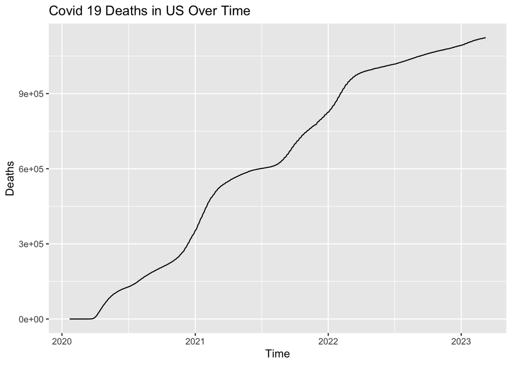

```r
US_deaths <- global %>%
  filter(Country_Region == 'US') %>%
  arrange(date)

US_deaths_plot <- ggplot(US_deaths, aes(x = date, y = deaths))+
  geom_line() +
   labs(title = 'Covid 19 Deaths in US Over Time', x = 'Time', y = 'Deaths')

US_deaths_plot
```

We can also plot it alongside the other top 5 countries as a comparison.

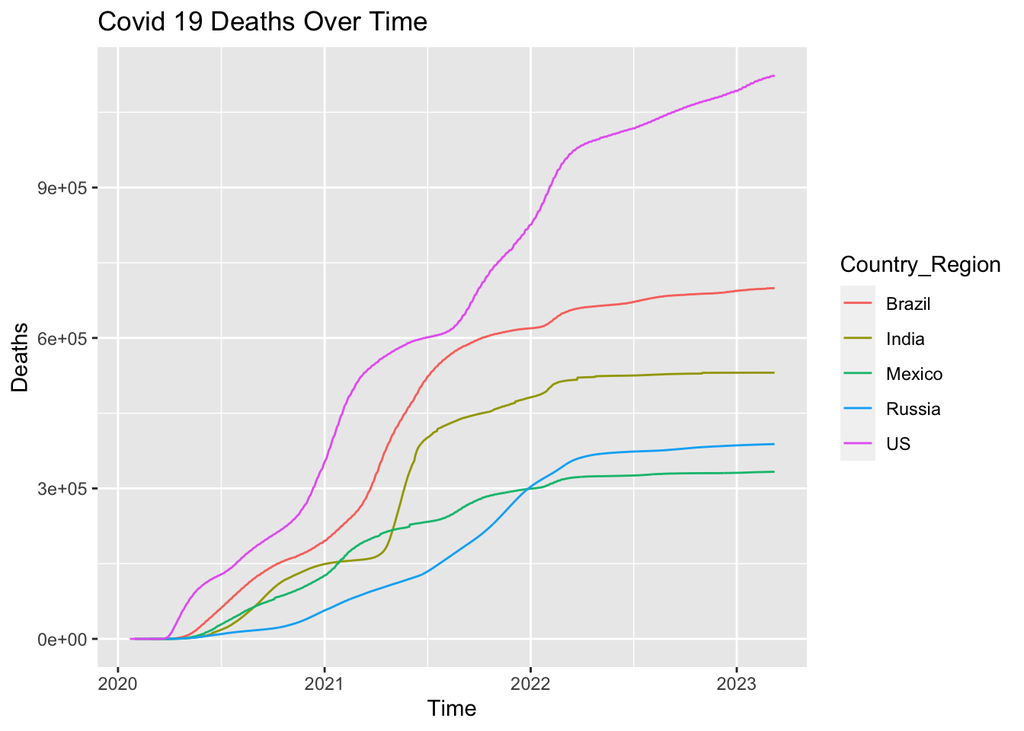

```r
Combined_deaths <- global %>%
  filter(Country_Region == 'US'| Country_Region == 'Brazil' | Country_Region == 'India' | Country_Region == 'Russia'| Country_Region == 'Mexico' ) %>%
  arrange(date)


Combined_deaths_plot <- ggplot(Combined_deaths, aes(x=date, y=deaths, group = Country_Region))+
  geom_line(aes(color = Country_Region))+
   labs(title = 'Covid 19 Deaths Over Time', x = 'Time', y = 'Deaths')

Combined_deaths_plot
```

We can also look at which countries had the least deaths on any given day. Since there are some regions (like Antarctica), that will have 0, or some countries that had 0 deaths in a day, we will filter those out.

```r
least_deaths <- global %>%
  group_by(Country_Region) %>%
  summarize(max_deaths = max(deaths, na.rm = TRUE)) %>%
  filter(max_deaths >0) %>%
  arrange(desc(max_deaths)) %>%
  tail(5)

least_deaths
```

```
## # A tibble: 5 × 2
##   Country_Region max_deaths
##   <chr>               <dbl>
## 1 Tonga                  13
## 2 Palau                   9
## 3 Korea, North            6
## 4 MS Zaandam              2
## 5 Nauru                   1
```

## State Analysis

Just as we viewed the countries with the most covid deaths, we can view the top 5 US states by covid deaths.

```r
most_deaths_US <- US %>%
  group_by(Province_State) %>%
  summarize(max_deaths = max(deaths, na.rm = TRUE)) %>%
  arrange(desc(max_deaths)) %>%
  head(5)

most_deaths_US
```

```
## # A tibble: 5 × 2
##   Province_State max_deaths
##   <chr>               <dbl>
## 1 California          35545
## 2 Florida             25840
## 3 Arizona             18846
## 4 Illinois            15289
## 5 New York            14219
```

```r
least_deaths_US <- US %>%
  group_by(Province_State) %>%
  summarize(max_deaths = max(deaths, na.rm = TRUE)) %>%
  filter(max_deaths >0) %>%
  arrange(desc(max_deaths)) %>%
  tail(5)

least_deaths_US
```

```
## # A tibble: 5 × 2
##   Province_State           max_deaths
##   <chr>                         <dbl>
## 1 Vermont                         230
## 2 Virgin Islands                  130
## 3 Northern Mariana Islands         41
## 4 American Samoa                   34
## 5 Grand Princess                    3
```

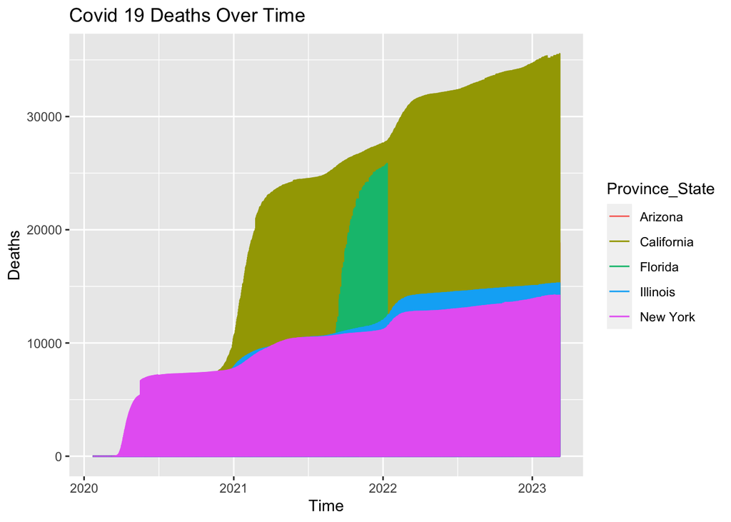

```r
State_deaths <- US %>%
  filter(Province_State == 'California'| Province_State == 'Florida' | Province_State == 'Arizona' | Province_State == 'Illinois'| Province_State == 'New York' ) %>%
  arrange(date)


State_deaths_plot <- ggplot(State_deaths, aes(x=date, y=deaths, group = Province_State))+
  geom_line(aes(color = Province_State))+
   labs(title = 'Covid 19 Deaths Over Time', x = 'Time', y = 'Deaths')

State_deaths_plot
```

```r
US_deaths_population <- US %>%
  group_by(Province_State, Population) %>%
  summarize(max_deaths = max(deaths, na.rm = TRUE)) %>%
  arrange(desc(max_deaths))
cor.test(US_deaths_population$Population, US_deaths_population$max_deaths, method = "pearson")
```

```
##
##  Pearson's product-moment correlation
##
## data:  US_deaths_population$Population and US_deaths_population$max_deaths
## t = 102.28, df = 3277, p-value < 2.2e-16
## alternative hypothesis: true correlation is not equal to 0
## 95 percent confidence interval:
##  0.8642037 0.8805483
## sample estimates:
##       cor
## 0.8726201
```

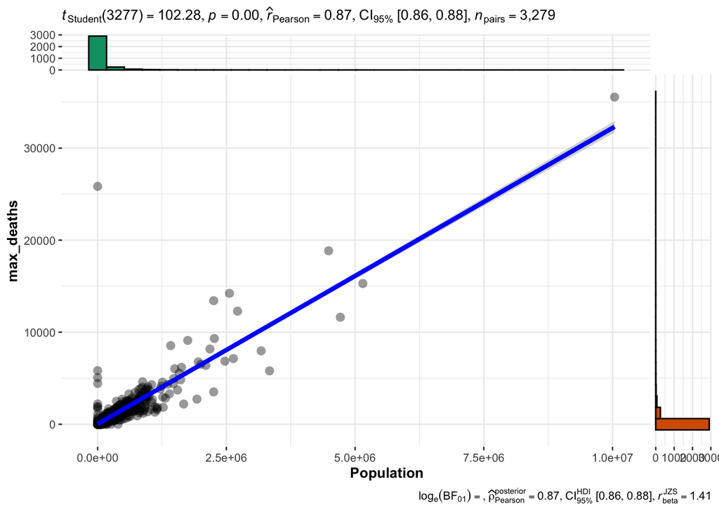

```r
ggscatterstats(data = US_deaths_population, x = Population, y = max_deaths)
```

## Conclusions and Bias

This report looked at covid deaths both by country and by states in the US. Unsurprisingly, it was found that both the countrys and states with the highest covid deaths were areas with lsarge populations. This generally makes sense, however there are other factors that should also be considered. Reporting of deaths may have varied, especially globally where different policies for reporting were put in place, and some countries may not have reported at all. There are also serveral other factors that could have impacted covid deaths beyond population. Such factors include varying healthcare systems, variation in regulations such as lockdown and mask policies, access to vaccines, and many others.